# Senior Theses

## Case study: senior theses

```r
theses <- read.csv("sample-theses.csv")
str(theses)
```

```
## 'data.frame':    339 obs. of  2 variables:
##  $ year     : int  1970 1992 1991 1978 2016 1949 2007 2007 1973 1940 ...
##  $ checkouts: int  3 0 1 3 1 2 0 1 1 0 ...
```

**Question 1**: What is the average number of times a thesis is checked out?

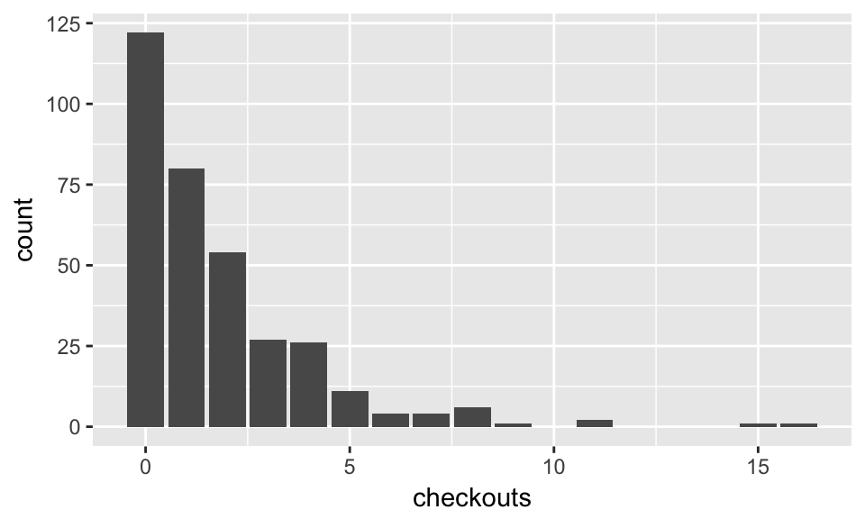

```r
qplot(x = checkouts, data = theses, geom = "bar")
```

```r
theses %>%
  summarize(mean(checkouts),
            median(checkouts))
```

```
##   mean(checkouts) median(checkouts)
## 1        1.740413                 1
```

**Question 1**: What is the average number of times a thesis is checked out?

**Confidence interval on one mean**

\[ \bar{x} \pm t^* \times s/\sqrt n \]

```r
n <- nrow(theses)
x_bar <- mean(theses$checkouts)
s <- sd(theses$checkouts)
x_bar + c(1, -1) * qt(.025, df = n - 1) * s / sqrt(n)
```

```
## [1] 1.498635 1.982191
```

**Question 2**: Is the distribution of theses uniform in time?

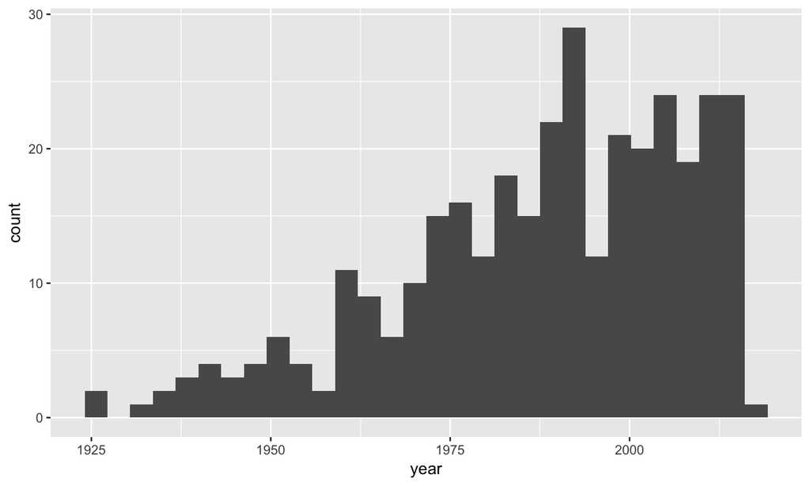

```r
qplot(x = year, data = theses, geom = "histogram")
```

**Question 2**: Is the distribution of theses uniform in time?

**Chi-squared goodness of fit test**

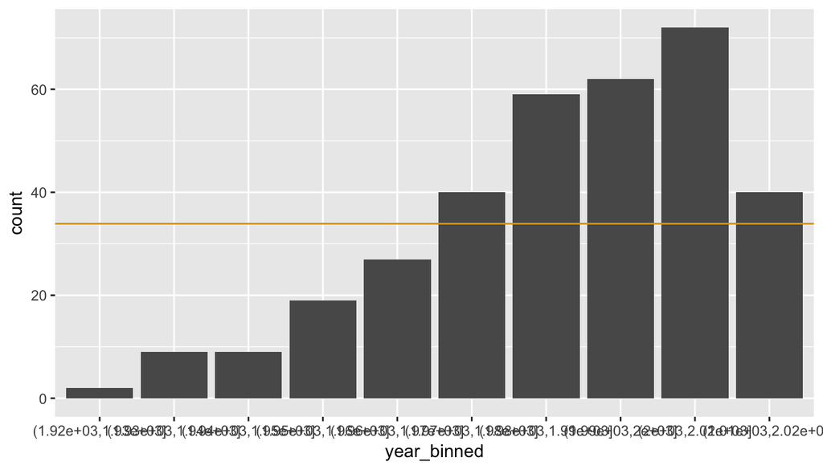

```r
year_binned <- cut(theses$year, seq(from = 1920, to = 2020, by = 10))
qplot(year_binned) +
  geom_hline(yintercept = length(year_binned)/10,
             color = "goldenrod")
```

**Question 2**: Is the distribution of theses uniform in time?

**Chi-squared goodness of fit test**

```r
(obs <- table(year_binned))
```

```
## year_binned
## (1.92e+03,1.93e+03] (1.93e+03,1.94e+03] (1.94e+03,1.95e+03]
##                   2                   9                   9
## (1.95e+03,1.96e+03] (1.96e+03,1.97e+03] (1.97e+03,1.98e+03]
##                  19                  27                  40
## (1.98e+03,1.99e+03]    (1.99e+03,2e+03]    (2e+03,2.01e+03]
##                  59                  62                  72
## (2.01e+03,2.02e+03]
##                  40
```

```r
(exp <- length(year_binned)/10)
```

```
## [1] 33.9
```

```r
(chisq_obs <- sum((obs - exp)^2/exp))
```

```
## [1] 161.4425
```

**Question 2**: Is the distribution of theses uniform in time?

**Chi-squared goodness of fit test**

```r
pchisq(chisq_obs, df = length(obs) - 1, lower.tail = FALSE)
```

```
## [1] 3.724151e-30
```

**Question 3**: What is the relationship between the age of a thesis and the number of checkouts?

```r
head(theses)
```

```
##   year checkouts
## 1 1970         3
## 2 1992         0
## 3 1991         1
## 4 1978         3
## 5 2016         1
## 6 1949         2
```

```r
theses <- theses %>%
  mutate(age = 2017 - year)
head(theses)
```

```
##   year checkouts age
## 1 1970         3  47
## 2 1992         0  25
## 3 1991         1  26
## 4 1978         3  39
## 5 2016         1   1
## 6 1949         2  68
```

**Question 3**: What is the relationship between the age of a thesis and the number of checkouts?

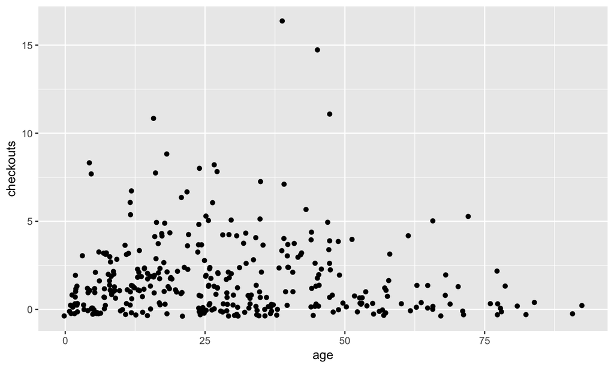

```r
qplot(x = age, y = checkouts, data = theses, geom = "jitter")
```

**Question 3**: What is the relationship between the age of a thesis and the number of checkouts?

```r
m1 <- lm(checkouts ~ age, data = theses)
summary(m1)
```

```
##
## Call:
## lm(formula = checkouts ~ age, data = theses)
##
## Residuals:
##     Min      1Q  Median      3Q     Max
## -1.9378 -1.6323 -0.7545  0.4899 14.3270
##
## Coefficients:
##              Estimate Std. Error t value Pr(>|t|)
## (Intercept)  1.937802   0.215004   9.013   <2e-16 ***
## age         -0.006789   0.006069  -1.119    0.264
## ---
## Signif. codes:  0 '***' 0.001 '**' 0.01 '*' 0.05 '.' 0.1 ' ' 1
##
## Residual standard error: 2.262 on 337 degrees of freedom
## Multiple R-squared:  0.0037, Adjusted R-squared:  0.0007439
## F-statistic: 1.252 on 1 and 337 DF,  p-value: 0.264
```

**Question 3**: What is the relationship between the age of a thesis and the number of checkouts?

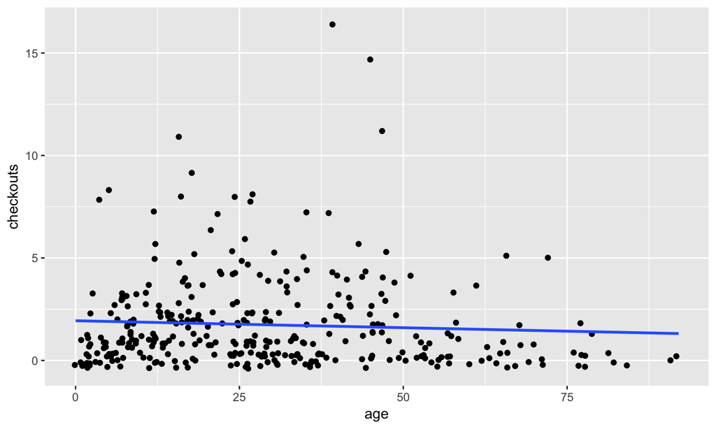

```r
qplot(x = age, y = checkouts, data = theses, geom = "jitter") +
  stat_smooth(method = "lm", se = FALSE)
```

## Poisson Regression

```r
m2 <- glm(checkouts ~ age, data = theses, family = "poisson")
summary(m2)
```

```
##
## Call:
## glm(formula = checkouts ~ age, family = "poisson", data = theses)
##
## Deviance Residuals:
##     Min       1Q   Median       3Q      Max
## -1.9749  -1.8039  -0.6166   0.3767   6.6111
##
## Coefficients:
##              Estimate Std. Error z value Pr(>|z|)
## (Intercept)  0.667888   0.070854   9.426   <2e-16 ***
## age         -0.004025   0.002099  -1.918   0.0552 .
## ---
## Signif. codes:  0 '***' 0.001 '**' 0.01 '*' 0.05 '.' 0.1 ' ' 1
##
## (Dispersion parameter for poisson family taken to be 1)
##
##     Null deviance: 848.84  on 338  degrees of freedom
## Residual deviance: 845.08  on 337  degrees of freedom
## AIC: 1429.4
##
## Number of Fisher Scoring iterations: 6
```

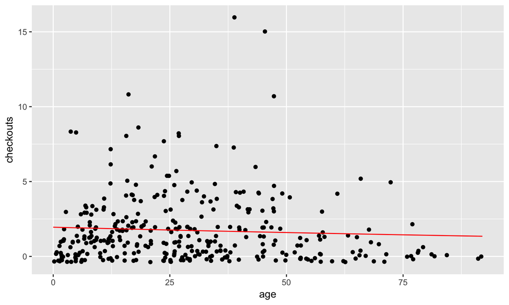

```r
qplot(x = age, y = checkouts, data = theses, geom = "jitter") +
  stat_function(fun = function(age) {exp(coef(m2)[1] + coef(m2)[2] * age)},
                color = "red")
```

```r
t2 <- theses %>%
  filter(year > 1994)
m2 <- glm(checkouts ~ age, data = t2, family = "poisson")
summary(m2)
```

```
##
## Call:
## glm(formula = checkouts ~ age, family = "poisson", data = t2)
##
## Deviance Residuals:
##     Min       1Q   Median       3Q      Max
## -2.4893  -1.3885  -0.3515   0.4554   4.2511
##
## Coefficients:
##             Estimate Std. Error z value Pr(>|z|)
## (Intercept) -0.15959    0.15243  -1.047    0.295
## age          0.06145    0.01060   5.796  6.8e-09 ***
## ---
## Signif. codes:  0 '***' 0.001 '**' 0.01 '*' 0.05 '.' 0.1 ' ' 1
##
## (Dispersion parameter for poisson family taken to be 1)
##
##     Null deviance: 298.81  on 144  degrees of freedom
## Residual deviance: 264.10  on 143  degrees of freedom
## AIC: 541.4
##
## Number of Fisher Scoring iterations: 5
```

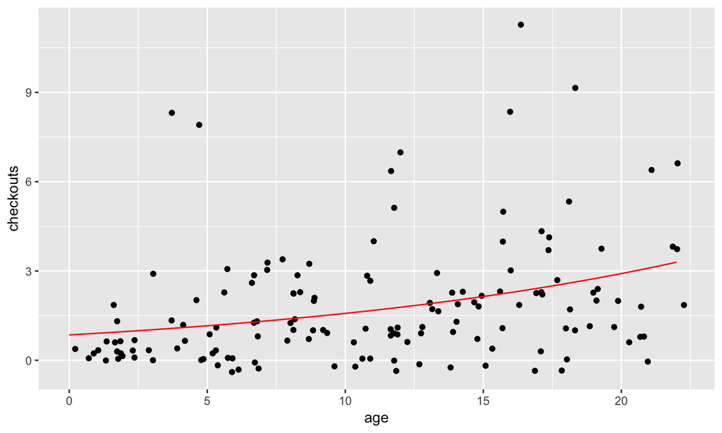

```r
qplot(x = age, y = checkouts, data = t2, geom = "jitter") +
  stat_function(fun = function(age) {exp(coef(m2)[1] + coef(m2)[2] * age)},
                color = "red")
```

## Ground truth

## From the library's database…

```r
theses_lib <- read.csv("library_theses_data.csv")
head(theses_lib)
```

```
##   year checkouts
## 1 1916         1
## 2 1917         2
## 3 1917         0
## 4 1918         0
## 5 1920         0
## 6 1920         0
```

**Question 1**: What is the average number of times a thesis is checked out?

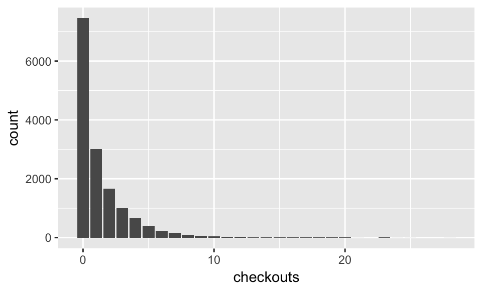

```r
qplot(x = checkouts, data = theses_lib, geom = "bar")
```

```r
theses_lib %>%
  summarize(mean(checkouts),
            median(checkouts))
```

```
##   mean(checkouts) median(checkouts)
## 1        1.332394                 0
```

**Question 2**: Is the distribution of theses uniform in time?

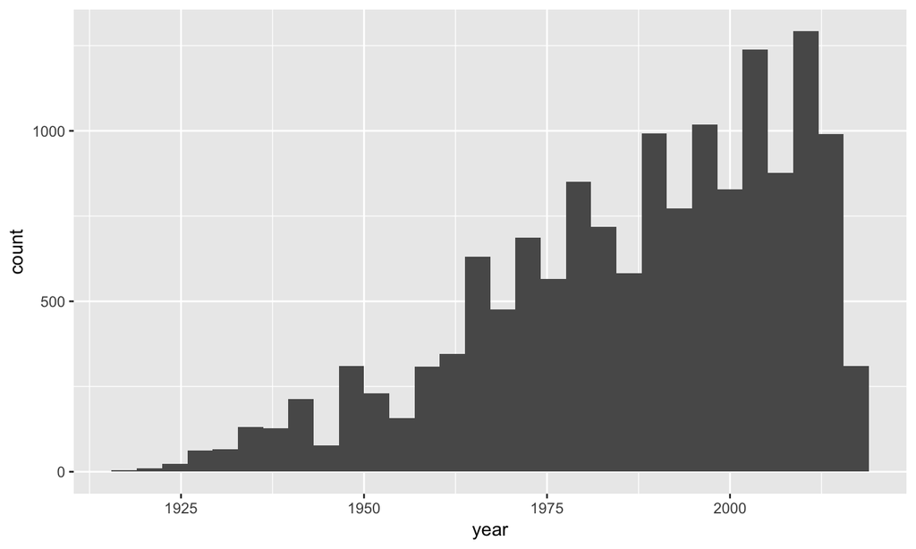

```r
qplot(x = year, data = theses_lib, geom = "histogram")
```

**Question 3**: What is the relationship between the age of a thesis and the number of checkouts?

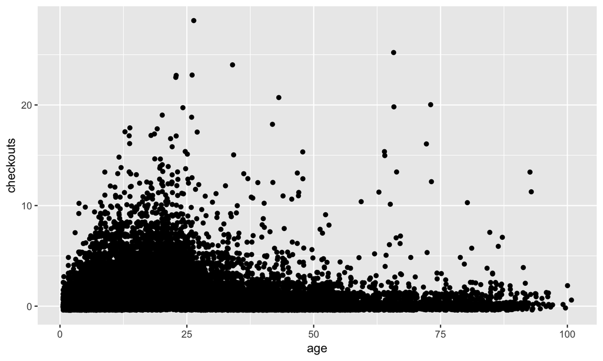

```r
theses_lib <- theses_lib %>%
  mutate(age = 2017 - year)
qplot(x = age, y = checkouts, data = theses_lib, geom = "jitter")
```

## Poisson Regression

```r
t3 <- theses_lib %>%
  filter(year > 1994)
m3 <- glm(checkouts ~ age, data = t3, family = "poisson")
summary(m3)
```

```
##
## Call:
## glm(formula = checkouts ~ age, family = "poisson", data = t3)
##
## Deviance Residuals:
##     Min       1Q   Median       3Q      Max
## -2.7209  -1.4842  -0.3773   0.6152   6.6148
##
## Coefficients:
##              Estimate Std. Error z value Pr(>|z|)
## (Intercept) -0.094822   0.021335  -4.444 8.82e-06 ***
## age          0.063801   0.001443  44.208  < 2e-16 ***
## ---
## Signif. codes:  0 '***' 0.001 '**' 0.01 '*' 0.05 '.' 0.1 ' ' 1
##
## (Dispersion parameter for poisson family taken to be 1)
##
##     Null deviance: 16368  on 6552  degrees of freedom
## Residual deviance: 14343  on 6551  degrees of freedom
## AIC: 26682
##
## Number of Fisher Scoring iterations: 5
```

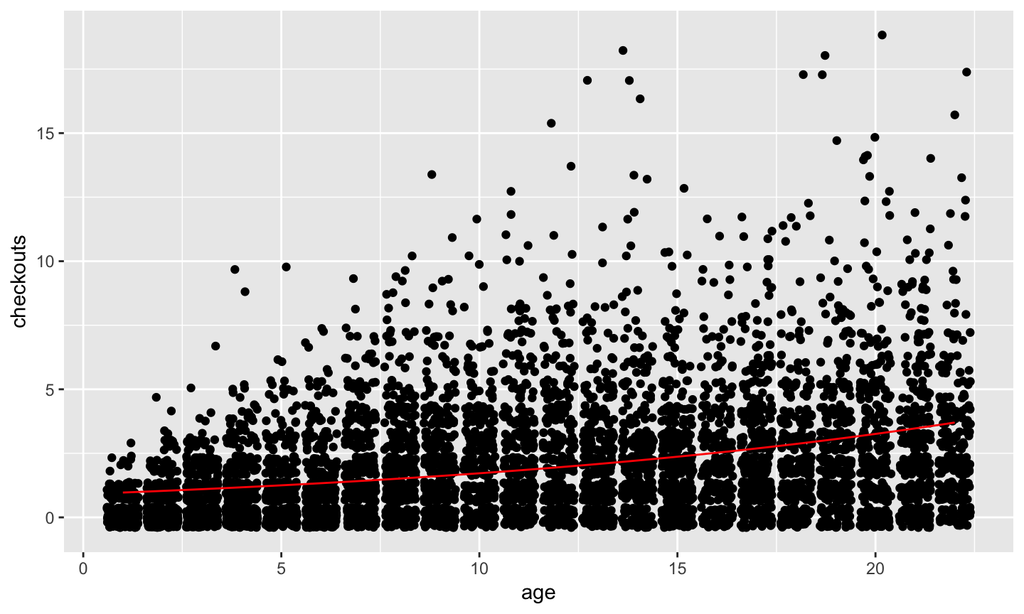

```r
qplot(x = age, y = checkouts, data = t3, geom = "jitter") +
  stat_function(fun = function(age) {exp(coef(m3)[1] + coef(m3)[2] * age)},
                color = "red")
```

## How'd we do?

```r
coef(m2) # our data
```

```
## (Intercept)         age
## -0.15958898  0.06145069
```

```r
coef(m3) # library's data
```

```
## (Intercept)         age
## -0.09482197  0.06380102
```